# Week 13: Gibbs Sampling and Langevin Proposals

STAT 536 — Statistical Computing

Soumojit Das

Fall 2026

# Gibbs Sampling

## Where We Are

- Metropolis–Hastings works with any proposal $q(y \mid x)$. We choose the proposal and its scale, and the goal of the choice is a large ESS.
- The random walk proposes $Y = x + Z$, $Z \sim \Normal(0, s^2)$, the same way wherever $x$ is: the target enters only through the accept step, and the scale $s$ is found by trial.
- This week, two ways to let the target shape the proposal. Gibbs sampling draws each coordinate from the target’s own full conditional distribution.
- Langevin proposals and Hamiltonian Monte Carlo use the slope of $\log\pi$ to aim the proposal.
- Then Stan, which runs a version of Hamiltonian Monte Carlo.

where $q(y \mid x)$: the proposal density from $x$ to $y$; $x$, $Y$: the current state and the proposal; $Z$: the step; $s$: its standard deviation; ESS: the effective sample size; $\pi$: the target.

## A Slice of the Joint Density

Target: $x = (x_1, x_2) \sim \Normal(\mathbf{0}, \boldsymbol\Sigma)$, $\boldsymbol\Sigma = \bigl(\begin{smallmatrix}1 & \rho\\ \rho & 1\end{smallmatrix}\bigr)$. Hold $x_2$ fixed: the joint density along that line, rescaled to integrate to 1, is the distribution of $x_1$ given $x_2$, narrower than its marginal (grey).

## Full Conditional Distributions

**Definition.** The full conditional of $x_j$ is its distribution given all the other coordinates:

$$\pi(x_j \mid x_{-j}) = \pi(x_j \mid x_1, \ldots, x_{j-1}, x_{j+1}, \ldots, x_d)$$

- $\pi(x_j \mid x_{-j}) \propto \pi(x_1, \ldots, x_d)$, as a function of $x_j$.
- The full conditional is the joint over the marginal, $\pi(x)/\pi(x_{-j})$, and the marginal is free of $x_j$.
- Treat the other coordinates as constants and find the part that depends on $x_j$.
- Recall kernels from week 7: when that part is a kernel we know, the full conditional is that distribution, and we can sample from it.
- Bivariate normal, unit variances, correlation $\rho$: as a function of $x_1$, $\log\pi(x) = -\frac{(x_1 - \rho x_2)^2}{2(1 - \rho^2)} + \text{const}$, so $x_1 \mid x_2 \sim \Normal(\rho x_2,\ 1 - \rho^2)$.

where $x = (x_1, \ldots, x_d)$: the state; $x_j$: its $j$th coordinate; $x_{-j}$: all coordinates but the $j$th; $\pi$: the target; $\pi(x_{-j})$: the marginal density of $x_{-j}$.

## The Gibbs Sampler

**The Gibbs Sampler (Geman and Geman, 1984)**

Target $\pi(x)$, $x = (x_1, \ldots, x_d)$; start $x^{(0)}$ with $\pi(x^{(0)}) > 0$. Sweep $t + 1$, in a fixed order (systematic scan):

- Draw $x_1^{(t+1)} \sim \pi(x_1 \mid x_2^{(t)}, \ldots, x_d^{(t)})$.
- Draw $x_2^{(t+1)} \sim \pi(x_2 \mid x_1^{(t+1)}, x_3^{(t)}, \ldots, x_d^{(t)})$.
- $\vdots$
- Draw $x_d^{(t+1)} \sim \pi(x_d \mid x_1^{(t+1)}, \ldots, x_{d-1}^{(t+1)})$.
- Each draw uses the newest values of the other coordinates.
- No proposal scale to tune, and every draw is kept: nothing is rejected.
- Each full conditional must be a distribution we can sample from.

where $x^{(t)}$: the state after $t$ sweeps; $\pi(x_j \mid \cdot)$: the full conditional of $x_j$; $d$: the number of coordinates.

## One Sweep by Hand

Target $x = (x_1, x_2) \sim \Normal(\mathbf{0}, \boldsymbol\Sigma)$, with unit variances and correlation $\rho$. Its full conditionals:

$$x_1 \mid x_2 \sim \Normal(\rho x_2,\ 1 - \rho^2), \qquad x_2 \mid x_1 \sim \Normal(\rho x_1,\ 1 - \rho^2)$$

- $\rho = 0.6$, current state $x = (-2.2, 1.8)$.
- Update $x_1$: $x_1 \mid x_2 = 1.8 \sim \Normal(0.6 \times 1.8,\ 1 - 0.6^2) = \Normal(1.08, 0.64)$.
- Update $x_2$: $x_2 \mid x_1 \sim \Normal(0.6\,x_1,\ 0.64)$, at the new $x_1$.
- The two updates are one sweep. The old value of a coordinate plays no part in its update.

where $\rho$: the target’s correlation; $\Normal(m, s^2)$: the normal distribution with mean $m$ and variance $s^2$.

## Gibbs on a Bivariate Normal

Target: $\Normal(\mathbf{0}, \boldsymbol\Sigma)$, unit variances, correlation $\rho$ (the slider). Step: one update; Play: whole sweeps.

## What the Chain Does

- One coordinate moves at a time: every segment of the path is parallel to an axis.
- No draw is rejected: every update gives a new state.
- After many sweeps the share of states inside the 95% contour settles near 0.95.
- Raise $\rho$: the conditionals narrow to standard deviation $\sqrt{1 - \rho^2}$, the moves shorten, and the trace of $x_1$ moves more slowly.

where $\rho$: the target’s correlation; the 95% contour: the ellipse that holds 95% of the target’s probability; trace: $x_1$ after each sweep.

## When Gibbs Is Slow

Recall $\Normal(\mathbf{0}, \boldsymbol\Sigma)$ with correlation $\rho$: a sweep draws $X_1^{(t+1)}$ given $X_2^{(t)}$, itself drawn given $X_1^{(t)}$.

$$X_1^{(t+1)} = \rho X_2^{(t)} + \sqrt{1 - \rho^2}\,Z = \rho\bigl(\rho X_1^{(t)} + \sqrt{1 - \rho^2}\,Z'\bigr) + \sqrt{1 - \rho^2}\,Z = \rho^2 X_1^{(t)} + \bigl(\rho\sqrt{1 - \rho^2}\,Z' + \sqrt{1 - \rho^2}\,Z\bigr)$$

- The noise in the last bracket has variance $\rho^2(1 - \rho^2) + (1 - \rho^2) = 1 - \rho^4$: week 11’s AR(1) with coefficient $\rho^2$, and stationary variance $(1 - \rho^4)/(1 - \rho^4) = 1$.
- Recall week 11: an AR(1) has $\kappa = (1 + \text{coefficient})/(1 - \text{coefficient})$ and $\text{ESS} = N/\kappa$, so here $\text{ESS}/N = (1 - \rho^2)/(1 + \rho^2)$.
- Runs of 200,000 sweeps: $\text{ESS}/N$ = 0.599, 0.106, 0.00988 at $\rho$ = 0.5, 0.9, 0.99; the formula gives 0.600, 0.105, 0.0100.
- Gibbs moves along the axes and a correlated target lies along the diagonal: the larger $\rho$, the shorter each move. At $\rho = 0.99$, about 100 sweeps for one effective draw.

where $X_j^{(t)}$: coordinate $j$ after $t$ sweeps; $Z$, $Z'$: independent $\Normal(0, 1)$ draws; $N$: the number of sweeps; $\kappa$: the inflation factor.

## Gibbs Is Metropolis–Hastings with Acceptance 1

- Update coordinate $j$: the proposal keeps $y_{-j} = x_{-j}$ and draws $y_j$ from the full conditional, so
  $$q(y \mid x) = \pi(y_j \mid x_{-j}), \qquad q(x \mid y) = \pi(x_j \mid y_{-j}) = \pi(x_j \mid x_{-j})$$
- The joint is the full conditional times the marginal: $\pi(x) = \pi(x_j \mid x_{-j})\,\pi(x_{-j})$ and $\pi(y) = \pi(y_j \mid x_{-j})\,\pi(x_{-j})$. In the Hastings ratio of week 12,
  $$R(x, y) = \frac{\pi(y)\,q(x \mid y)}{\pi(x)\,q(y \mid x)} = \frac{\pi(y_j \mid x_{-j})\,\pi(x_{-j}) \cdot \pi(x_j \mid x_{-j})}{\pi(x_j \mid x_{-j})\,\pi(x_{-j}) \cdot \pi(y_j \mid x_{-j})} = 1, \qquad \boxed{\alpha(x, y) = \min(1, 1) = 1}$$
- Each coordinate update is a Metropolis–Hastings step that is never rejected: take $X \sim \pi$, redraw $X_j$ from its full conditional, and still $X \sim \pi$.
- A sweep is $d$ such updates in turn, so it keeps $\pi$ stationary too.

where $x$, $y$: the current state and the proposal, equal except in coordinate $j$; $X$: the state as a random variable; $x_{-j}$: all coordinates but the $j$th; $\pi(x_j \mid x_{-j})$: the full conditional; $\pi(x_{-j})$: the marginal of $x_{-j}$; $q(y \mid x)$: the proposal density; $R$: the Hastings ratio; $\alpha$: the acceptance probability.

## Example: Normal Data, Mean and Variance Unknown

- **The setting:** an instrument measures a quantity $\mu$. Each measurement is $\mu$ plus a normal error with standard deviation $\sigma$, and both $\mu$ and $\sigma$ are unknown.
- **Data:** $n = 20$ measurements: 104, 118, 97, 121, 104, 122, 96, 112, 83, 103, 95, 102, 99, 90, 105, 102, 104, 90, 98, 108. Their mean is $\bar x = 102.65$, their standard deviation 10.13.
- **Model:** $X_i \mid \mu, \omega \iid \Normal(\mu, 1/\omega)$, $i = 1, \ldots, n$, with $\omega = 1/\sigma^2$, the precision.
- **Priors**, independent: $\mu \sim \Normal(\mu_0, \tau_0^2) = \Normal(100, 5^2)$; $\omega \sim \Gam(a, b) = \Gam(2, 100)$, which is an Inverse-Gamma$(a, b)$ prior on $\sigma^2$.
- **The task:** the joint posterior of $(\mu, \omega)$, which is no distribution we have named. Recall conjugacy: Normal–Normal for $\mu$ when $\sigma^2$ is known, Inverse-Gamma for $\sigma^2$ when $\mu$ is known.

where $X_i$: measurement $i$; $\mathbf{x} = (x_1, \ldots, x_n)$: the data; $\mu_0$, $\tau_0^2$: the prior mean and variance of $\mu$; $\Gam(a, b)$: shape $a$, rate $b$; Inverse-Gamma$(a, b)$: shape $a$, scale $b$.

## Normal Model: The Two Full Conditionals

Likelihood times the two priors; each of the $n$ likelihood factors is $\propto \omega^{1/2}e^{-\omega(x_i - \mu)^2/2}$:

$$\textstyle\pi(\mu, \omega \mid \mathbf{x}) \propto \omega^{n/2}\exp\bigl\{-\frac{\omega}{2}\sum_i (x_i - \mu)^2\bigr\}\,\exp\bigl\{-(\mu - \mu_0)^2/(2\tau_0^2)\bigr\}\,\omega^{a - 1}e^{-b\omega}$$

- In $\mu$, the factors in $\omega$ alone are constants: Normal–Normal conjugacy, with $\sigma^2 = 1/\omega$ held fixed. Precisions add:
  $$\mu \mid \omega, \mathbf{x} \sim \Normal(\mu_n, \tau_n^2), \qquad 1/\tau_n^2 = 1/\tau_0^2 + n\omega, \qquad \mu_n = \tau_n^2\bigl(\mu_0/\tau_0^2 + \omega\,n\bar x\bigr)$$
- In $\omega$, the prior of $\mu$ is a constant:
  $$\textstyle\omega^{n/2}\exp\bigl\{-\frac{\omega}{2}\sum_i (x_i - \mu)^2\bigr\}\,\omega^{a - 1}e^{-b\omega} = \omega^{a + n/2 - 1}\exp\bigl\{-\omega\bigl[b + \frac12\sum_i (x_i - \mu)^2\bigr]\bigr\}$$
- This is a Gamma kernel, the Inverse-Gamma conjugacy for $\sigma^2$ with $\mu$ held fixed: $\omega \mid \mu, \mathbf{x} \sim \Gam\bigl(a + \frac n2,\ b + \frac12\sum_i (x_i - \mu)^2\bigr)$.

where $\mathbf{x}$: the $n$ data, mean $\bar x$; $\omega$: the precision; $\mu_0, \tau_0^2, a, b$: prior parameters; $\mu_n, \tau_n^2$: mean, variance of $\mu$ given $\omega$, $\mathbf{x}$.

## Normal Model: The Sampler in R

```r
x <- c(104, 118, 97, 121, 104, 122, 96, 112, 83, 103,
       95, 102, 99, 90, 105, 102, 104, 90, 98, 108)
n <- length(x); mu0 <- 100; tau0 <- 5; a <- 2; b <- 100
N <- 21000; draws <- matrix(NA, N, 2)
mu <- 100; omega <- 0.01                      # the start
set.seed(536)
for (t in 1:N) {
  prec  <- 1 / tau0^2 + n * omega             # 1 / tau_n^2: precisions add
  mu    <- rnorm(1, (mu0 / tau0^2 + omega * sum(x)) / prec, sqrt(1 / prec))
  omega <- rgamma(1, a + n / 2, rate = b + sum((x - mu)^2) / 2)
  draws[t, ] <- c(mu, omega)
}
```

- One pass of the loop is one sweep: $\mu$ from its normal full conditional, then $\omega$ from its Gamma full conditional at the new $\mu$.
- `rgamma(1, shape, rate = )`: $\Gam(a, b)$ with $b$ a rate.
- The first 1,000 sweeps are dropped; the other 20,000 are kept.

## Normal Model: Results

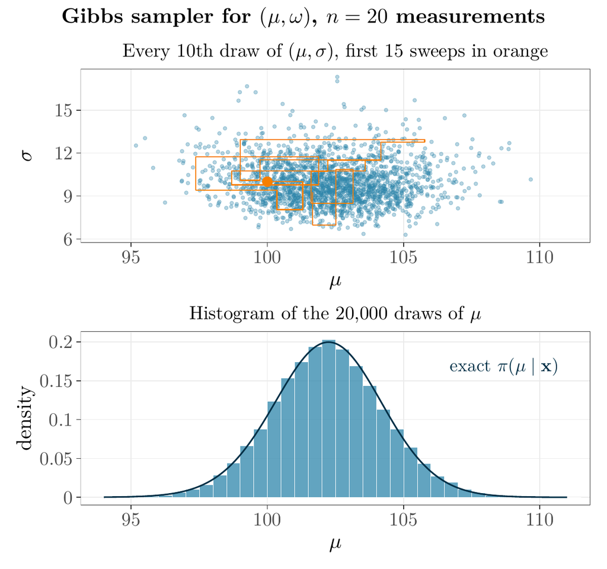

- Top: draws of $(\mu, \sigma)$; the first sweeps from $\mu^{(0)} = 100$, $\omega^{(0)} = 0.01$ form a staircase.
- Bottom: draws of $\mu$; dark: its exact posterior density, by one-dimensional quadrature.
- 20,000 sweeps after 1,000. $\mu$: mean 102.23 (SE 0.015) and SD 2.05, against the exact 102.21 and 2.04. $\sigma$: mean 9.97, exact 9.97.
- Correlation of $\mu$ and $\sigma$: $-0.04$. ESS for $\mu$ about 20,000 of 20,000 sweeps: each sweep is close to an independent draw.

where $\sigma = 1/\sqrt\omega$; SE: Monte Carlo standard error; SD: standard deviation.

## Example: Coal-Mining Disasters

- **Data:** explosions in British coal mines with ten or more deaths, counted per year: $x_i$ in year $i$ (Jarrett, 1979; `boot::coal`).
- $n = 112$ years, 1851 to 1962; 191 explosions, at most 6 in a year; 33 years had none.
- **The question:** the counts fall at some point. In which year, and from what rate to what rate? Three unknowns: two rates and a year.
- **Model:** $X_i \sim \Pois(\lambda_1)$ for $i \le k$, $\Pois(\lambda_2)$ for $i > k$, independent; $\lambda_1, \lambda_2 \iid \Gam(a, b)$, $a = 2$, $b = 1$; $k$ uniform on $\{1, \ldots, n - 1\}$, independent of the rates.

where year $i$ is $1850 + i$; $k$: the last year at $\lambda_1$; $\Gam(a, b)$: shape $a$, rate $b$.

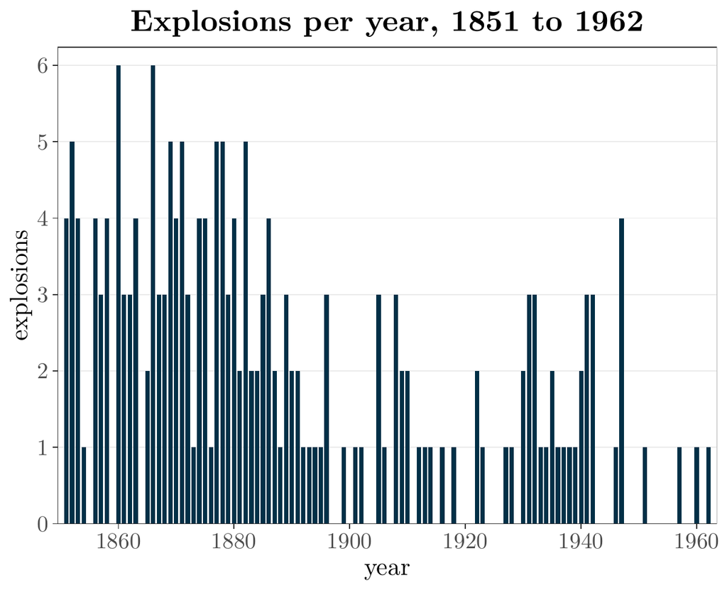

## Change Point: The Three Full Conditionals

Likelihood times priors, with the uniform prior on $k$ a constant:

$$\begin{aligned}
\pi(\lambda_1, \lambda_2, k \mid \mathbf{x}) &\propto \prod_{i \le k}\lambda_1^{x_i}e^{-\lambda_1}\prod_{i > k}\lambda_2^{x_i}e^{-\lambda_2} \cdot \lambda_1^{a - 1}e^{-b\lambda_1}\,\lambda_2^{a - 1}e^{-b\lambda_2} \\
&= \lambda_1^{a + S_k - 1}e^{-(b + k)\lambda_1}\;\lambda_2^{a + S_n - S_k - 1}e^{-(b + n - k)\lambda_2}
\end{aligned}$$

- Recall Gamma–Poisson from week 7, $\Gam\bigl(a + \sum_i x_i,\ b + n\bigr)$ with $a$, $b$ for week 7’s $\alpha$, $\beta$, here on each stretch of years: $\lambda_1 \mid \lambda_2, k, \mathbf{x} \sim \Gam(a + S_k,\ b + k)$ and $\lambda_2 \mid \lambda_1, k, \mathbf{x} \sim \Gam(a + S_n - S_k,\ b + n - k)$.
- In $k$, drop the factors free of $k$:
  $$\pi(k \mid \lambda_1, \lambda_2, \mathbf{x}) \propto \lambda_1^{S_k}e^{-k\lambda_1}\,\lambda_2^{S_n - S_k}e^{-(n - k)\lambda_2} \propto \Bigl(\frac{\lambda_1}{\lambda_2}\Bigr)^{S_k}e^{-k(\lambda_1 - \lambda_2)} = w_k, \qquad k = 1, \ldots, n - 1$$
- A discrete distribution on $n - 1$ values, $w_k/\sum_j w_j$: compute $\log w_k = S_k\log(\lambda_1/\lambda_2) - k(\lambda_1 - \lambda_2)$, subtract the largest (recall log-sum-exp, week 1), exponentiate, and draw with `sample()`.

where $S_k = \sum_{i \le k} x_i$; $k$: the last year at $\lambda_1$; $a, b$: the prior’s shape and rate; $w_k$: the weight of $k$.

## Change Point: Results

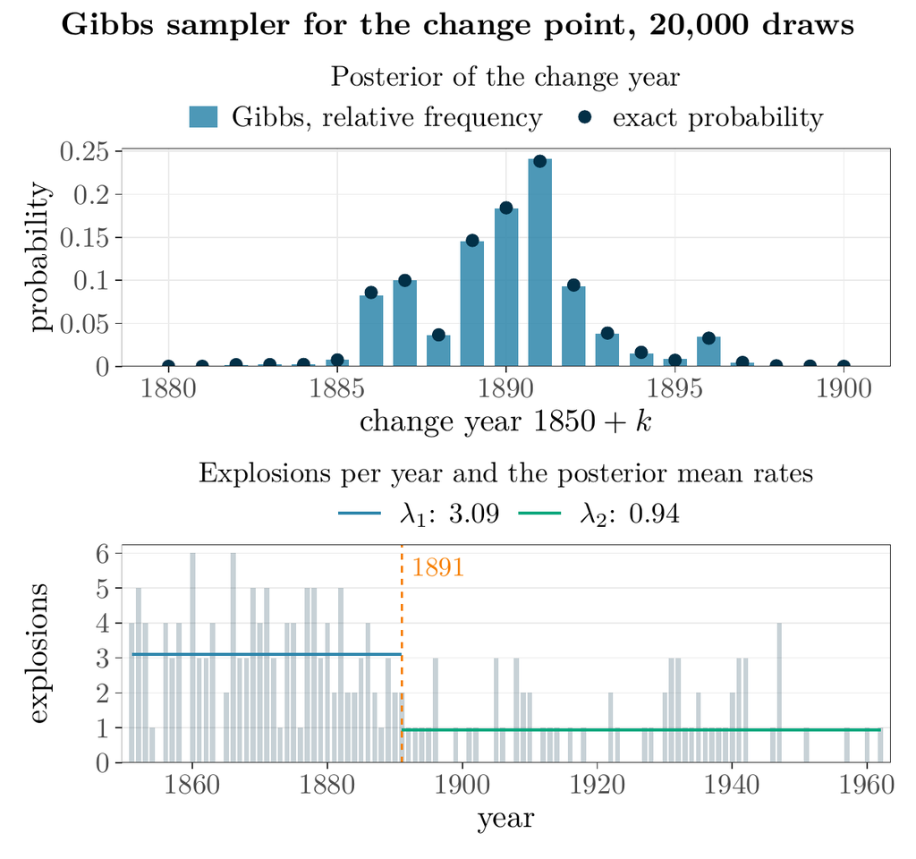

- Top: posterior of $k$; bars: Gibbs; points: exact, the rates integrated out,
  $$\pi(k \mid \mathbf{x}) \propto \frac{\Gamma(a + S_k)\,\Gamma(a + S_n - S_k)}{(b + k)^{a + S_k}\,(b + n - k)^{a + S_n - S_k}}$$
- Mode 1891: exact 0.238, Gibbs 0.241; over all $k$ the two differ by at most 0.003.
- Bottom: the posterior means of $\lambda_1$ and $\lambda_2$, 3.09 and 0.94 a year (exact 3.09, 0.94), drawn before and after 1891.

where $k$: the last year at $\lambda_1$, the year $1850 + k$; $\Gamma$: the gamma function; Gibbs: 20,000 sweeps after 1,000, from $k = 56$.

## Strengths and Limits of Gibbs Sampling

- No proposal to tune and no rejections: each update is an exact draw from a full conditional.
- Every full conditional must be a distribution we can sample. It is easiest when it is a conjugate form from week 7 or a finite set of values, as for the change year $k$.
- Logistic regression has the log-posterior terms $y_i\eta_i - \log(1 + e^{\eta_i})$, $\eta_i = \beta_0 + \beta_1 \times (\text{predictor } i)$: in $\beta_0$ alone, or in $\beta_1$ alone, the kernel of no named distribution. Each coordinate then needs a sampler of its own, such as ARS (week 4) or a Metropolis step.
- Strong posterior correlation between coordinates slows it: on the bivariate normal, $\text{ESS}/N = (1 - \rho^2)/(1 + \rho^2)$.
- **Blocked Gibbs:** draw correlated coordinates together from their joint full conditional, when that is a distribution we can sample; here $(x_1, x_2)$ as one block is an exact draw from $\pi$.

where $y_i$: the binary outcome of case $i$; $\eta_i$: its linear predictor; $\beta_0$, $\beta_1$: the intercept and the slope; $\rho$: the correlation; ESS: the effective sample size; $N$: the number of sweeps; $\pi$: the target.

# Gradients and Langevin Proposals

## A Proposal That Uses the Slope of $\log\pi$

- The random walk proposes $Y = x + sZ$: the same cloud around every $x$, wherever the density is.
- Gibbs uses the target itself, and needs every full conditional.
- The slope of $\log\pi$ at $x$ says which way the density rises. It costs one derivative and needs no conditional.
- The Langevin proposal is built from it in three parts: a step along the slope, noise, and an accept step.
- Each part repairs what the one before lacks: the step alone stops at the mode, the noise leaves a bias, and the accept step removes it.

where $x$: the current state; $Y$: the proposal; $Z \sim \Normal(\mathbf{0}, \mathbf{I})$; $s$: the standard deviation of the random-walk step; $\pi$: the target.

## The Random-Walk Proposal from One Point

Target: $x = (x_1, x_2) \sim \Normal(\mathbf{0}, \boldsymbol\Sigma)$, $\boldsymbol\Sigma = \bigl(\begin{smallmatrix}1 & 0.9\\ 0.9 & 1\end{smallmatrix}\bigr)$. Random-walk step: standard deviation $s$.

- From $(-1.2, 0.2)$, outside the 95% contour, about half of the cloud still lands where $\pi$ is lower.

## The Gradient of $\log\pi$

Target: $\Normal(\mathbf{0}, \boldsymbol\Sigma)$, unit variances, $\rho = 0.9$. Its gradient $\nabla\log\pi(x)$ is the pair of slopes:

$$\log\pi(x) = -\tfrac{x_1^2 - 2\rho x_1x_2 + x_2^2}{2(1 - \rho^2)} + \text{const}, \qquad \tfrac{\partial\log\pi}{\partial x_1} = -\tfrac{x_1 - \rho x_2}{1 - \rho^2}, \quad \tfrac{\partial\log\pi}{\partial x_2} = -\tfrac{x_2 - \rho x_1}{1 - \rho^2}$$

## Reading the Gradient Field

- $\nabla\log\pi(x) = (\partial\log\pi/\partial x_1, \ldots, \partial\log\pi/\partial x_d)$, here $-\boldsymbol\Sigma^{-1}x$, points where $\log\pi$, and so $\pi$, rises fastest.
- Off the ridge, the long axis of the contours (the line $x_1 = x_2$), the arrows point nearly straight across to it, the steepest way up; the mode lies along the ridge, in another direction.
- The target is long along the ridge, standard deviation $\sqrt{1 + \rho} = 1.38$, and narrow across it, $\sqrt{1 - \rho} = 0.32$.
- The slope is steep across the ridge and gentle along it: per unit of distance from the mode, the gradient grows by $1/(1 - \rho) = 10$ across and by $1/(1 + \rho) \approx 0.53$ along.
- A constant drops out, $\nabla\log(c\,\tilde\pi) = \nabla\log\tilde\pi$: a posterior’s unknown constant is never needed.

where $\boldsymbol\Sigma$: unit variances, $\rho = 0.9$; $\tilde\pi$: the target without its constant $c$.

## Euler Steps Along the Gradient

The first part of the proposal: from the current state, a step along the gradient.

$$x_{t+1} = x_t + \tfrac{\epsilon^2}{2}\nabla\log\pi(x_t)$$

- Euler’s method follows a motion $dz/dt = f(z)$ by straight steps $z \gets z + h\,f(z)$: here $f = \nabla\log\pi$, $h = \epsilon^2/2$.
- Bivariate normal, $\rho = 0.9$, $x_t = ({-}2.6,\ 1.2)$, $\epsilon = 0.3$: $\nabla\log\pi(x_t) = (19.37,\ {-}18.63)$, $\tfrac{\epsilon^2}{2}\nabla\log\pi(x_t) = (0.87,\ {-}0.84)$, $x_{t+1} = ({-}1.73,\ 0.36)$.
- The step has length $\tfrac{\epsilon^2}{2}\lVert\nabla\log\pi(x_t)\rVert$. Here: $0.045 \times 26.88 = 1.21$. On the ridge at $(1, 1)$: $0.045 \times 0.74 = 0.033$.
- Doubling $\epsilon$ makes every step four times as long. The slope at the start is used for the whole step, so a large $\epsilon$ overshoots the ridge, and a larger one diverges.

where $x_t$: the state after $t$ steps; $\epsilon$: the step size; $\lVert\cdot\rVert$: the length of a vector; the ridge: the long axis of the contours, the line $x_1 = x_2$; $\gets$: replace by; $z$, $f$, $h$: a state, its rate of change, a time step.

## Euler Steps on the Bivariate Normal

Target: $\Normal(\mathbf{0}, \boldsymbol\Sigma)$, unit variances, correlation $\rho = 0.9$. Start: $({-}2.6,\ 1.2)$; step size $\epsilon$ on the slider.

## Adding Noise: Euler–Maruyama

The second part: noise. The Euler path ends at the mode, one point and no sample from $\pi$.

$$x_{t+1} = x_t + \tfrac{\epsilon^2}{2}\nabla\log\pi(x_t) + \epsilon Z_t, \qquad Z_t \iid \Normal(\mathbf{0}, \mathbf{I})$$

- Euler–Maruyama: Euler’s method with Gaussian noise added at every step.
- $\epsilon Z_t$: a fresh normal step with standard deviation $\epsilon$ in each coordinate, independent of everything before it.
- The gradient term pulls the state toward higher density; the noise term pushes it off in a random direction.
- Small steps approach the Langevin diffusion, a continuous-time process with stationary distribution $\pi$.

where $x_t$: the state after $t$ steps; $\nabla\log\pi$: the gradient of $\log\pi$; $\epsilon$: the step size; $Z_t$: the noise at step $t$.

## Euler–Maruyama on the Bivariate Normal

Target: $\Normal(\mathbf{0}, \boldsymbol\Sigma)$, unit variances, $\rho = 0.9$. The switches turn the gradient and the noise on or off.

## What the Switches Show

- Gradient alone: the path ends at the mode.
- Noise alone: a random walk with no accept step. After $t$ steps each coordinate has variance $t\epsilon^2$ around the start, and nothing brings the state back.
- Both: the states scatter around the mode and along the ridge, as $\pi$ does.
- Count the states inside the 95% contour: at $\epsilon = 0.5$, 0.81 of them, where 0.95 belong. Too many fall outside.

where $t$: the number of steps; $\epsilon$: the step size; the 95% contour: the ellipse that holds 95% of the target’s probability; the ridge: the long axis of the contours, the line $x_1 = x_2$; the widget’s share inside the contour: counted after the first 50 steps.

## The Balance of Gradient and Noise

A step that keeps the target takes a draw from $\pi$ to a draw from $\pi$. Check one step on $\Normal(0, 1)$, where the slope is $-x$:

- $X' = X + \tfrac{\epsilon^2}{2}(-X) + \epsilon Z = \bigl(1 - \tfrac{\epsilon^2}{2}\bigr)X + \epsilon Z$, with $X \sim \Normal(0, 1)$, the target, and $Z$ independent of $X$.
  $$\Var(X') = \underbrace{\bigl(1 - \tfrac{\epsilon^2}{2}\bigr)^2}_{\text{the gradient shrinks}} + \underbrace{\epsilon^2}_{\text{the noise adds}} = 1 - \epsilon^2 + \tfrac{\epsilon^4}{4} + \epsilon^2 = \boxed{1 + \tfrac{\epsilon^4}{4}}$$
- At $\epsilon = 0.5$: $\Var(X') = 0.766 + 0.250 = 1.016$, against the target’s 1. The step nearly keeps the target; the excess is $\epsilon^4/4$.
- A gradient step of $a$ in place of $\epsilon^2/2$ gives $(1 - a)^2 + \epsilon^2 = 1 - 2a + \epsilon^2 + a^2$, and $-2a + \epsilon^2 = 0$ only when $a = \epsilon^2/2$: the reason the gradient step is written $\epsilon^2/2$.

where $X$, $X'$: the state before and after one step; $Z \sim \Normal(0, 1)$: the noise; $\epsilon$: the step size; $a$: a size for the gradient step.

## The Step Size Leaves a Bias

With no accept step, the chain settles on a distribution wider than the target.

- Recall one step on $\Normal(0, 1)$, $X_{t+1} = \bigl(1 - \tfrac{\epsilon^2}{2}\bigr)X_t + \epsilon Z_t$: from variance $v$ it gives variance $\bigl(1 - \tfrac{\epsilon^2}{2}\bigr)^2 v + \epsilon^2$.
- The variance stops changing where the two agree, the stationary variance of this AR(1) chain (week 11):
  $$v = \bigl(1 - \tfrac{\epsilon^2}{2}\bigr)^2 v + \epsilon^2 \quad\Longrightarrow\quad v = \frac{\epsilon^2}{1 - (1 - \epsilon^2/2)^2} = \frac{\epsilon^2}{\epsilon^2 - \epsilon^4/4} = \boxed{\frac{1}{1 - \epsilon^2/4}} > 1$$
- The target’s variance is 1. The chain’s is 1.07 at $\epsilon = 0.5$ and $4/3$ at $\epsilon = 1$: it samples $\Normal(0, 4/3)$ in place of $\Normal(0, 1)$.
- On the bivariate normal at $\epsilon = 0.5$: variance 2.67 times the target’s across the ridge and 1.03 times along it, which leaves 0.81 of the states inside the 95% contour.
- A smaller $\epsilon$ shrinks the bias, and each step then moves the chain less.

where $X_t$: the state after $t$ steps; $Z_t \iid \Normal(0, 1)$; $\epsilon$: the step size, $0 < \epsilon < 2$; $v$: the variance of the state; AR(1): $X_{t+1} = \rho X_t + \sigma Z_t$, here with $\rho = 1 - \epsilon^2/2$, $\sigma = \epsilon$; the ridge: the long axis of the contours, the line $x_1 = x_2$.

## The Langevin Proposal with the Hastings Correction

$$Y = x + \tfrac{\epsilon^2}{2}\nabla\log\pi(x) + \epsilon Z, \qquad Z \sim \Normal(\mathbf{0}, \mathbf{I})$$

- The third part, the accept step: use one Euler–Maruyama step as the proposal of Metropolis–Hastings. Its density is normal, centered at the gradient step from $x$:
  $$q(y \mid x) = \phi\bigl(y;\ x + \tfrac{\epsilon^2}{2}\nabla\log\pi(x),\ \epsilon^2\mathbf{I}\bigr)$$
- Asymmetric: the center depends on the gradient at the starting point, so $q(y \mid x) \ne q(x \mid y)$ in general, and the Hastings correction of week 12 is needed:
  $$\alpha(x, y) = \min\Bigl(1,\ \frac{\pi(y)\,q(x \mid y)}{\pi(x)\,q(y \mid x)}\Bigr)$$
- With the correction, $\pi$ is stationary for every $\epsilon$: the accept step removes the bias of the step size. This is MALA, the Metropolis-adjusted Langevin algorithm (Roberts and Tweedie, 1996).

where $x$: the current state; $Y$, $y$: the proposal; $\epsilon$: the step size; $Z$: the noise; $\phi(y; \mathbf{m}, \mathbf{S})$: the normal density, mean $\mathbf{m}$, covariance $\mathbf{S}$; $\alpha$: the acceptance probability.

## The Langevin Proposal from One Point

Target: $\Normal(\mathbf{0}, \boldsymbol\Sigma)$, unit variances, correlation $\rho = 0.9$. Switch off: the random walk with the same spread.

- From $x = (-1.2, 0.2)$ at $\epsilon = 0.5$: 0.92 of the proposals land where $\pi$ is higher (random walk: about half).

## What the Gradient Does to the Proposal

- The gradient moves the center of the cloud; the spread stays $\epsilon$ in every direction.
- Off the ridge the move is large: from $(-1.2, 0.2)$ at $\epsilon = 0.5$ the center shifts by $(0.91,\ {-}0.84)$, toward the ridge.
- On the ridge it is small: from $(1, 1)$ the center shifts by $({-}0.07,\ {-}0.07)$, and the cloud is nearly the random walk’s.
- Too large a step throws the center across the ridge and out the other side.
- Landing where $\pi$ is higher is no goal in itself: in the long run a chain moves to lower density as often as to higher. The goal stays a large ESS.

where $\epsilon$: the step size; the ridge: the long axis of the contours, the line $x_1 = x_2$; ESS: the effective sample size.

## The Langevin Chain on the Bivariate Normal

Target: $\Normal(\mathbf{0}, \boldsymbol\Sigma)$, unit variances, correlation $\rho = 0.9$. The switches turn each part of the step on or off.

- At $\epsilon = 0.5$: 0.95 of the states inside the 95% contour (0.81 without the accept step); acceptance 0.71.

## Langevin Against the Random Walk

- **The goal:** a large ESS, as in week 12; the acceptance rate sits beside it as a diagnostic. Each sampler at the best of the settings tried, $s$ = 0.5, 1, 1.4 and $\epsilon$ = 0.3, 0.5, 0.6.

| Bivariate normal, $\rho = 0.9$ | Setting | Acceptance rate | $\text{ESS}/N$ of $x_1$ |
| --- | --- | --- | --- |
| random walk | $s = 1.4$ | 0.22 | 0.042 |
| Langevin proposal, Hastings correction | $\epsilon = 0.6$ | 0.55 | 0.029 |

- The Langevin proposal accepts more often and still has the smaller ESS on this target.
- Along the ridge the gradient is small: each step there is a random walk of size $\epsilon$.
- The narrow direction across the ridge limits $\epsilon$: past 0.6 the steps overshoot and are rejected more often (acceptance 0.21 at $\epsilon = 0.9$), and $\text{ESS}/N$ never passes 0.030 for $\epsilon$ up to 0.9.

where $s$: the standard deviation of the random-walk step, the same in both coordinates; $\epsilon$: the Langevin step size; the ridge: the long axis of the contours, the line $x_1 = x_2$; ESS: the effective sample size; $N$: the number of iterations, one evaluation of the target each for both samplers.

## Distance Covered in $L$ Steps

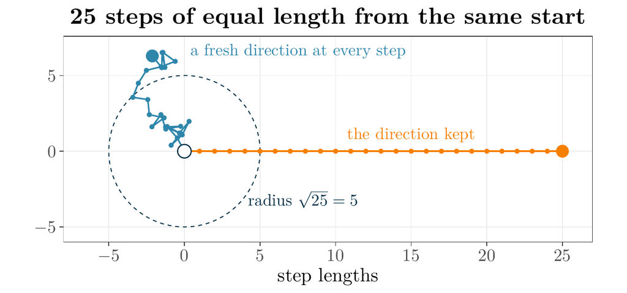

- Blue: a fresh direction at every step, as the Langevin chain moves along the ridge. The steps partly cancel: after $L$ steps the end is about $\sqrt L$ step lengths away, here 5.
- Orange: one direction kept. The steps add up: $L$ step lengths, here 25.
- The 95% contour is 11.2 steps of size $\epsilon = 0.6$ long: about $11.2^2 \approx 126$ steps in fresh directions to cover it, 11 with the direction kept.

**The need:** a move that keeps its direction for many steps.

where $L$: the number of steps; dashed circle: radius $\sqrt L$, the root mean square distance over many such paths (this one ends 6.6 away).

## Notation

| Symbol | Meaning |
| --- | --- |
| $x = (x_1, \ldots, x_d)$, $x_{-j}$ | state; the state without $x_j$ |
| $\pi(x_j \mid x_{-j})$ | full conditional of $x_j$ |
| $x^{(t)}$ | state after $t$ sweeps |
| $\omega = 1/\sigma^2$ | precision |
| $\mu_n$, $\tau_n^2$ | mean, variance of $\mu$ given $\omega$, $\mathbf{x}$ |
| $a$, $b$ | shape, rate of a Gamma prior |
| $\lambda_1$, $\lambda_2$, $k$ | rates, last year at $\lambda_1$ |
| $S_k$, $w_k$ | $\sum_{i \le k} x_i$, weight of $k$ |

| Symbol | Meaning |
| --- | --- |
| $\nabla\log\pi(x)$ | gradient of $\log\pi$ |
| $\lVert\cdot\rVert$ | length of a vector |
| $\epsilon$, $Z_t$ | step size, $\Normal(\mathbf{0}, \mathbf{I})$ noise |
| $s$ | standard deviation of a random-walk step |
| $q(y \mid x)$ | proposal density from $x$ to $y$ |
| $\alpha(x, y)$ | acceptance probability |
| $u$, $w$ | $(x_1 + x_2)/\sqrt2$, $(x_1 - x_2)/\sqrt2$: along, across the ridge |

## Punchlines

- Gibbs draws each coordinate from its full conditional: Metropolis–Hastings with acceptance 1, no tuning.
- Gibbs moves along the axes: on the bivariate normal, $\text{ESS}/N = (1 - \rho^2)/(1 + \rho^2)$, 0.105 at $\rho = 0.9$.
- The gradient of $\log\pi$ gives the direction. A step of size $\epsilon$ leaves a bias, $1/(1 - \epsilon^2/4)$ in the variance on $\Normal(0, 1)$, and the Hastings step removes it.
- Along the ridge the Langevin chain is still a random walk of step $\epsilon$: on the bivariate normal its $\text{ESS}/N$ is 0.029, against 0.042 for the best random walk.